# *Лабораторна робота № 3*. Основи вибіркового методу

© [Сидоренко В. М.](https://www.linkedin.com/in/valeriy-sydorenko-6782279a/), 2024

2024-05-20

**Мета:** *засвоїти основи статистичного оцінювання характеристик випадкової величини на основі вибіркового підходу засобами мови програмування R; набути навичок роботи у середовищі RStudio із застосуванням концепції “грамотного програмування” із застосуванням пакету R Markdown*.

*Зауваження*. Див. [Основні функції R](http://aakinshin.net/ru/blog/r/functions/#section-strings) (Akinshin 2018), [Основи синтаксису LaTeX](https://ru.wikibooks.org/wiki/LaTeX) (Wikipedia 2018).

## Короткі теоретичні положення

**Вибірковий метод** (method of sampling) – статистичний метод дослідження загальних властивостей сукупності будь-яких об’єктів на основі вивчення властивостей лише частини цих об’єктів. Сукупність досліджуваних об’єктів, що цікавлять дослідника, називається **генеральною сукупністю (statistical population)**. А частина об’єктів, що підлягають вивченню, називають **вибірковою сукупністю** або **вибіркою (sample)**.

*Визначення*. **Вибіркою** об’єму $n$ називається випадковий вектор $X=(x_1, x_2,\dots,x_n)$, де $x_1, x_2,\dots,x_n$ – незалежні й однаково розподілені випадкові величини з функцією розподілення $F(x)$.

Простими словами, сенс і сила вибіркового методу полягає в тому, що можна взяти **не всі** (генеральну сукупність), а тільки **декілька** (вибірку з $n$ значень) випадкових значень певної випадкової величини $X$, що нас цікавить (зараплату по країні, долю людей, що проголусували за того, чи іншого кандидата, врожайність пшениці в регіоні тощо), і можна з достатньою точністю зробити висновки стосовно всієї генеральної скупності.

Таким чином, суть вибіркового методу як технології полягає в тому, щоби знизити розмірність вибірки і виразити закономірності у поведінці випадкової величини у вигляді невеликої кількості **числових** та **функціонаьних характеристик**.

Вся класична теорія вимірювань та метрологія ґрунтується на парадигмі вибіркового методу. Нормування складових похибок вимірювань полягає у застосуванні вибіркового методу для оцінки низки статистичних характеристик похибки вимірювання як випадкової величини.

Етапи вибіркового методу представлені на рис. 1.

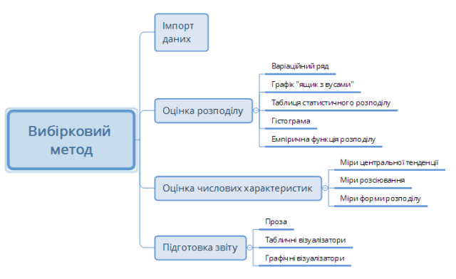

*Рис. 1. Етапи вибіркового методу*

## Короткі практичні зауваження

### Створення RMarkdown-документу

1. Завантажуємо [RStudio](https://www.rstudio.com/products/rstudio/download/).
2. Створюємо RMarkdown-документ у форматі [R Notebook](http://rmarkdown.rstudio.com/r_notebooks.html), вибравши відповідний пункт [меню](https://prnt.sc/gkpes4).

### Генерація електронного документу

Генерація електронного документу здійснюється натисканням комбінації *Ctrl+Shift+K*.

## Приклад виконання лабораторної роботи

### 1. Постановка задачі

1. Побудувати статистичний розподіл у вигляді інтервальної таблиці відносних частот.
2. Побудувати гістограму, теоретичну $f(x,a,\sigma)$ та емпіричну $f^*(x,\tilde{a},\tilde{\sigma})$ функції щільності на одному графіку.
3. Побудувати графіки теоретичної $F(x,a,\sigma)$ та емпіричної $F^*(x,\tilde{a},\tilde{\sigma})$ функції розподілу.
4. Побудувати п’ятиквантильний графік (boxplot) “ящик з вусами”.
5. Обчислити точкові незміщені і конзістентні оцінки вектору параметрів розподілу $(a,\sigma^2)$, математичного сподівання $m(x)$, дисперсії $D(x)$, СКВ $\sigma(x)$, центральних теоретичних моментів $3$-го $\mu_3$ і $4$-ого $\mu_4$ порядків, асиметрії $A_s$ та ексцесу $E_k$:
- написавши власну користувацьку функцію;
- за допомогою вбудованих засобів R.
6. Дані звести у таблицю:

Таблиця 1 – **Теоретичні та емпіричні (вибіркові) числові характеристики випадкової величини**

| Назва числової характеристики | теоретичне значення | Вибіркове значення, $n=100$ | Вибіркове значення, $n=1000$ |
| --- | --- | --- | --- |
| $a$ | $a$ | $\tilde a$ | $\tilde a$ |
| $\sigma$ | $\sigma$ | $\tilde{\sigma}$ | ${\tilde{\sigma}}$ |
| Математичне сподівання | $m(x)$ | $\tilde{m}(x)$ | $\tilde{m}(x)$ |
| Дисперсія | $D(x)$ | $\tilde{D}(x)$ | $\tilde{D}(x)$ |
| Виправлена дисперсія |  | $\tilde{\tilde{D}}(x)$ | $\tilde{\tilde{D}}(x)$ |
| СКВ | $\sigma(x)$ | $\tilde{\sigma}(x)$ | $\tilde{\sigma}(x)$ |
| Виправлене СКВ |  | $\tilde{\tilde\sigma}(x)$ | $\tilde{\tilde\sigma}(x)$ |
| Центральний момент $3$-го порядку | $\mu_3$ | $\tilde{\mu}_3$ | $\tilde{\mu}_3$ |
| Центральний момент $4$-го порядку | $\mu_4$ | $\tilde{\mu}_4$ | $\tilde{\mu}_4$ |
| Асимерія | $A_s$ | $\tilde{A}_s$ | $\tilde{A}_s$ |
| Ексцес | $E_k$ | $\tilde{E}_k$ | $\tilde{E}_k$ |

### 2. Виконання роботи (основні моменти)

Генеруємо вибірку з нормального розподілу з параметрами $a=$ 0, $\sigma=$ 1 об’єму $n=$ 100:

```r
set.seed(0) # фіксація параметрів генератора псевдовипадкових чисел
X <- rnorm(n, a, s) # генератор нормального розподілу
cat("\n", "Параметри вибірки:", "\n", "a = ", a, "\n" , "s = ", s, "\n" , "n = ", n, "\n")
```

```
 Параметри вибірки:
 a =  0
 s =  1
 n =  100
```

```r
cat("Перші елементи вибірки:", head(X))
```

```
Перші елементи вибірки: 1.262954 -0.3262334 1.329799 1.272429 0.4146414 -1.53995
```

```r
cat("Останні елементи вибірки:", tail(X))
```

```
Останні елементи вибірки: 0.596259 0.1197176 -0.2821739 1.455988 0.2290196 0.9965439
```

Будуємо варіаційний ряд.

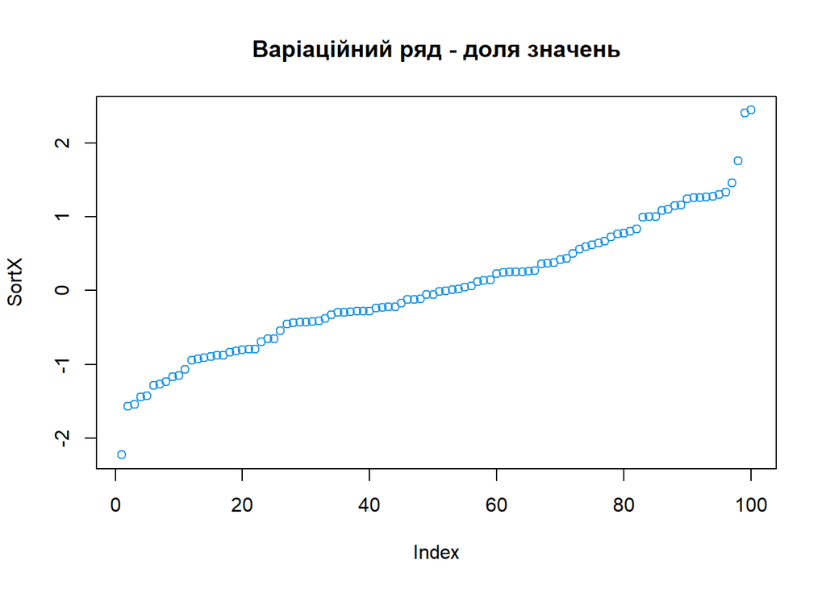

```r
SortX <- sort(X) # варіаційний ряд
plot(SortX, col=4)
title("Варіаційний ряд - доля значень")
```

```r
# dev.off()
```

Будуємо інтервальний статистичний розподіл і гістограму частот.

```r
1 + 1.332 * log(n)
```

```
[1] 7.134087
```

```r
# За замовчанням - "Sturges", заголовок відсутній
table(cut(X, nclass.Sturges(X))) # Вивід інтревального варіаційного ряду
```

```
 (-2.23,-1.64]  (-1.64,-1.06] (-1.06,-0.474] (-0.474,0.109]  (0.109,0.692]
             1             10             15             30             21
  (0.692,1.28]    (1.28,1.86]    (1.86,2.45]
            17              4              2
```

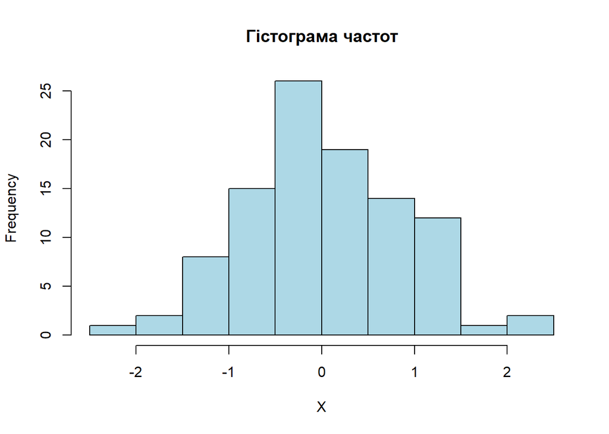

```r
hist(X, breaks=nclass.Sturges(X),
     col="Lightblue",
     main="Гістограма частот") # Кількість карманів за Стерджессом
```

Гістограма відносних частот.

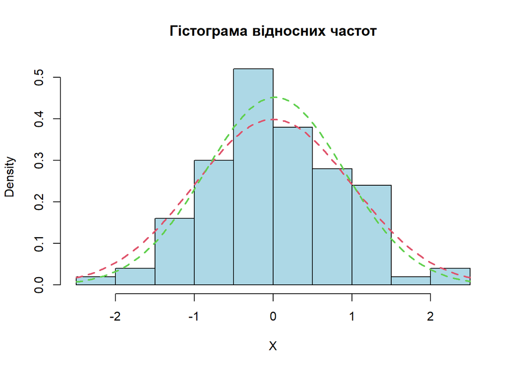

```r
hist(X,
     freq = FALSE,
     col = "Lightblue",
     main = "Гістограма відносних частот")
curve(dnorm(x, a, s), col = 2, lty = 2, lwd = 2, add = TRUE) # теоретична крива щільності розподілу
curve(dnorm(x, mean(X), sd(X)), col = 3, lty = 2, lwd = 2, add = TRUE) # емпірична крива щільності розподілу
```

Сумарні статистики.

Вивід сумарних статистик.

```r
summary(X)
```

```
    Min.  1st Qu.   Median     Mean  3rd Qu.     Max.
-2.22390 -0.56942 -0.03296  0.02267  0.62535  2.44136
```

Альтернативний варіант за допомогою спеціальних функцій:

```r
mean(X)
```

```
[1] 0.02266845
```

```r
sd(X)
```

```
[1] 0.8826502
```

```r
IQR(X)
```

```
[1] 1.19477
```

```r
kurtosis(X)
```

```
[1] 2.959992
```

```r
skewness(X)
```

```
[1] 0.2273757
```

Можна так:

Таблиця 2 – **Числові характеристики вибірки**

[output not shown]

Функція `describe()` з пакету `Hmisc` надає можливість вивести цілу низку сумарних оцінок характеристик вибірки:

```r
describe(X)
```

```
X
       n  missing distinct     Info     Mean      Gmd      .05      .10
     100        0      100        1  0.02267   0.9995 -1.29162 -1.07380
     .25      .50      .75      .90      .95
-0.56942 -0.03296  0.62535  1.23988  1.30084

lowest : -2.2239  -1.56378 -1.53995 -1.43759 -1.4251
highest: 1.3298   1.45599  1.7579   2.40465  2.44136
```

А можна написати власну функцію.

```r
my_summary <- function(X, ...) {
  cat("\n", "Оцінки статистичних характеристик вибірки:", "\n",
      "вибіркове математичне сподівання, m = ", mean(X), "\n",
      "Медіана, Ме = ", median(X) , "\n",
      "вибіркова дисперсія, s^2 = ", var(X), "\n" ,
      "вибіркове СКВ, s = ", sd(X), "\n" ,
      "Розмах, R = ", max(X) - min(X), "\n" ,
      "Інтерквартільний розмах, IQR = ", IQR(X), "\n",
      "Ексцес, Ek = ", kurtosis(X), "\n",
      "Асиметрія, As= ", skewness(X), "\n"
    )
}

my_summary(X,  na.rm=FALSE)
```

```
 Оцінки статистичних характеристик вибірки:
 вибіркове математичне сподівання, m =  0.02266845
 Медіана, Ме =  -0.03296148
 вибіркова дисперсія, s^2 =  0.7790714
 вибіркове СКВ, s =  0.8826502
 Розмах, R =  4.665265
 Інтерквартільний розмах, IQR =  1.19477
 Ексцес, Ek =  2.959992
 Асиметрія, As=  0.2273757
```

Ще один варіант представлення теоретичного і емпіричного розподілів.

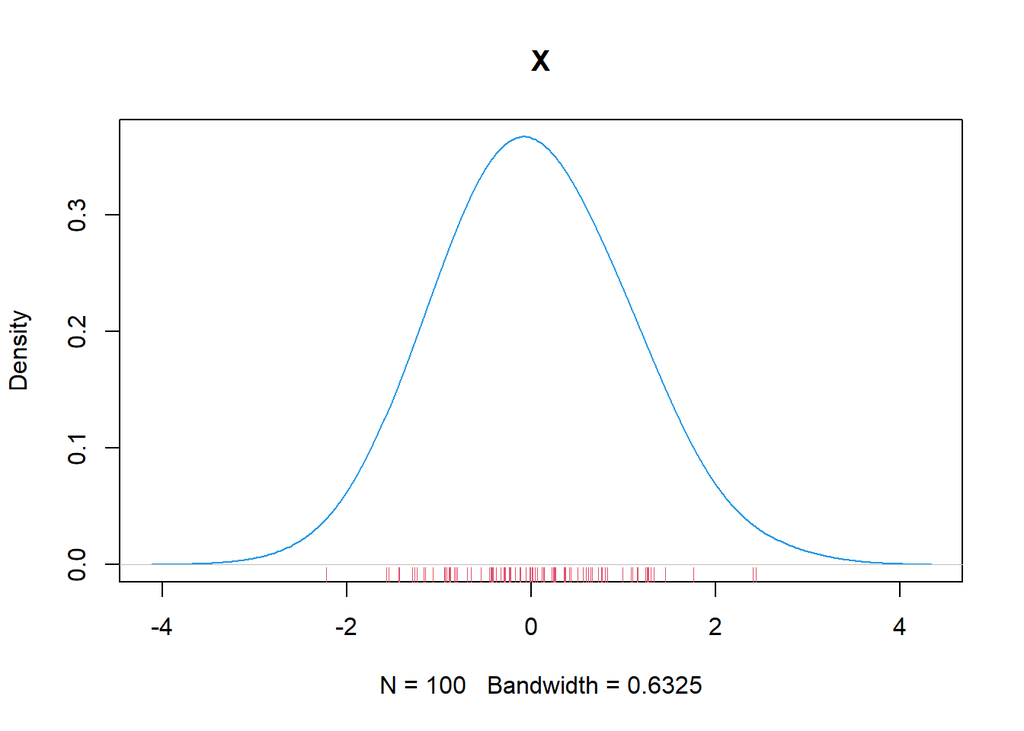

```r
plot(density(X, adjust=2), main="X", col=4)
rug(X, col=2) # Виділення місць точками з наібільшою щільністю значень
```

Емпірична функція росподілу F(x).

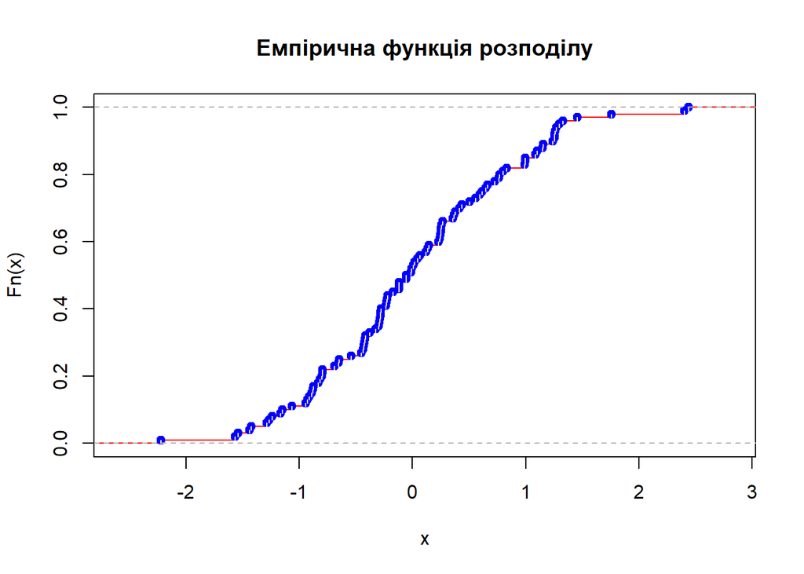

```r
# Fn <- ecdf(table(cut(X, nclass.Sturges(X))))

Fn <- ecdf(X)


## luxury plot
plot(Fn,
     verticals = TRUE,
     col.points = "blue",
     col.hor = "red",
     col.vert = "bisque",
     main = "Емпірична функція розподілу")
```

Побудова боксплотів (ящиків з вусами).

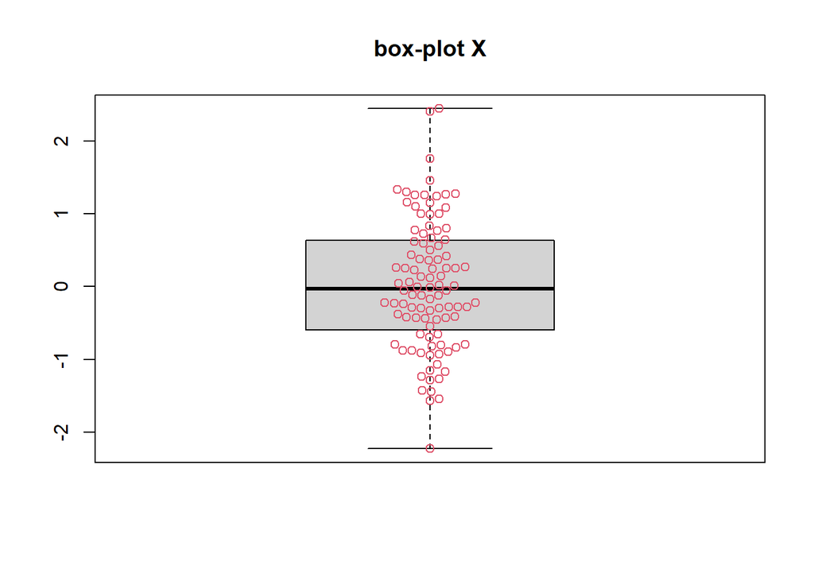

```r
# Ще одна альтернатива - "графік-вулик"
boxplot(X, main="box-plot X")  # вивід боксплоту
beeswarm(X, col=2, add=TRUE) # ДОДАВАННЯ "рою" з ефектом jutter
```

На практиці оптимальним може бути компактний варіант виводу основних графіків вибіркових характеристик. Наприклад, такий.

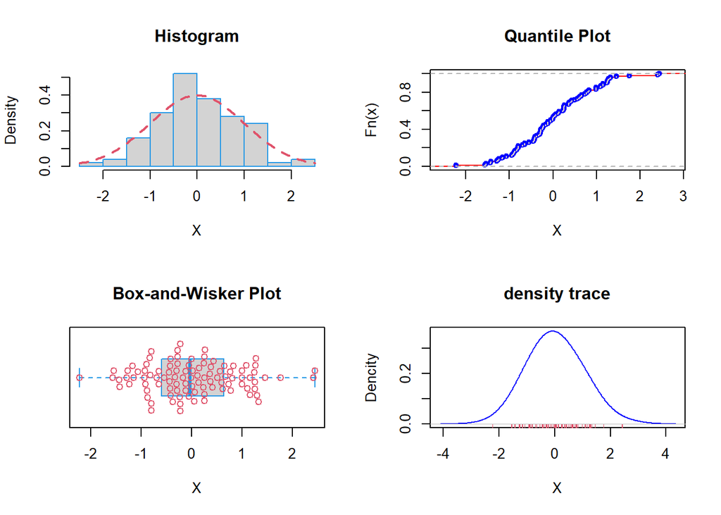

```r
op <- par(mfrow = c(2,2))

# Гістограма відносних частот
hist(X,
     freq = FALSE,
     col = "Lightgray",
     main="Histogram",
     border=4)

curve(dnorm(x, a, s),
      col = 2,
      lty = 2,
      lwd = 2,
      add = TRUE) # крива щільності

plot(Fn,
     main = "Quantile Plot",
     verticals = TRUE,
     col.points = "blue",
     col.hor = "red",
     col.vert = "bisque",
     xlab = "X",
     ylab = "Fn(x)")

boxplot(X,
        main = "Box-and-Wisker Plot",
        col = "Lightgray",
        border = 4,
        xlab = "X",
        ylab = "",
        horizontal = TRUE)  # боксплот

beeswarm(X,
         col = 2,
         add = TRUE,
         horizontal = TRUE) # ДОДАВАННЯ "рою" з ефектом jutter

plot(density(X, adjust=2),
     main = "density trace",
     xlab = "X",
     ylab = "Dencity",
     col="blue")

rug(X,
    col=2,
    main="fn(x)") # Виділення точками місць з найбільшою щільністю значень
```

```r
par(op) #Повертаємо параметри за замовчанням
```

**Результати моделювання зводимо у таблицю.**

Таблиця 3 – **Теоретичні та емпіричні (вибіркові) числові характеристики випадкової величини**

[output not shown]

## Порядок виконання лабораторної роботи.

1. Ознайомитися з короткими теоретичними положеннями та матеріалами методички для практичних робіт. **Варіанти індивідуальних завдань видаються індивідуально кожному**.
2. Вибрати варіант індивідуального завдання.
3. Створити проект, в основі якого лежить документ RMarkdown у форматі RNotebook, для розв’язання задачі згідно з отриманим варіантом. **За основу взяти RNotebook документ цієї методички**. Проект має містити наступні розділи (приблизний перелік задач):
1. Постановку задачі з детальним описом заданого розподілу і його параметрів.
2. Розв’язок задачі з необхідними коментарями.
3. Висновки.
4. Перелік посилань на основі bib-файлу.

## References

Akinshin, A. 2018. “Blog of Andrey Akinshin.” Article. http://aakinshin.net/ru/blog/r/functions/#section-strings.

Wikipedia. 2018. “LaTeX.” Book. https://ru.wikibooks.org/wiki/LaTeX.